# College Regularization

This is ISLR’s Chapter 6 Applied Section Problem 9

```r
library(ISLR)
library(leaps)
library(tidyverse)
library(glmnet)
library(pls)
data = College
set.seed(1)
sample = sample(1:nrow(data),nrow(data)*.7)
train = data[sample,]
test = data[-sample,]
x.trainmat = model.matrix(Apps~.,data = train)[,-1]
x.testmat = model.matrix(Apps~.,data = test)[,-1]
y = College$Apps
```

```r
linear = lm(Apps~.,data = train)
ridge = glmnet(x.trainmat,train$Apps,alpha = 0)
lasso = glmnet(x.trainmat,train$Apps,alpha = 1)
cv.fit = cv.glmnet(x.trainmat,train$Apps,alpha = 0)
bestlam_ridge = cv.fit$lambda.min
bestlam_ridge
```

```
[1] 393.4083
```

```r
cv.fit = cv.glmnet(x.trainmat,train$Apps,alpha=1)
bestlam_lasso = cv.fit$lambda.min
bestlam_lasso
```

```
[1] 2.099502
```

```r
ridge.pred = predict(ridge,s=bestlam_ridge,newx = x.testmat)
mean((ridge.pred-test$Apps)^2)
```

```
[1] 992828.6
```

```r
lasso.pred = predict(lasso,s=bestlam_lasso,newx = x.testmat)
mean((lasso.pred - test$Apps)^2)
```

```
[1] 993791.1
```

```r
lm.pred = predict(linear, test)
mean((lm.pred - test$Apps)^2)
```

```
[1] 996667.4
```

Here, we fit a PCR model to the training set, observing that the MSE is the lowest when the 16 and 17 princpal components are used, but the MSE drops off dramatically when ~3 principal components are used. We fit both models and compare the MSEs, seeing that the one with 16 principal components yields the lowest MSE

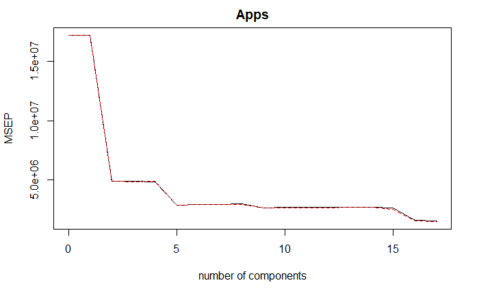

```r
pcr.fit = pcr(Apps~., data = data, subset = sample, scale = TRUE, validation = "CV")
validationplot(pcr.fit,val.type = "MSEP")
```

```r
summary(pcr.fit)
```

```
Data:   X dimension: 543 17
    Y dimension: 543 1
Fit method: svdpc
Number of components considered: 17

VALIDATION: RMSEP
Cross-validated using 10 random segments.
       (Intercept)  1 comps  2 comps  3 comps  4 comps  5 comps  6 comps  7 comps  8 comps  9 comps  10 comps  11 comps  12 comps
CV            4149     4147     2212     2208     2200     1703     1714     1718     1723     1636      1638      1639      1640
adjCV         4149     4150     2210     2207     2214     1696     1709     1714     1720     1631      1633      1635      1636
       13 comps  14 comps  15 comps  16 comps  17 comps
CV         1650      1648      1622      1268      1240
adjCV      1646      1645      1596      1256      1229

TRAINING: % variance explained
      1 comps  2 comps  3 comps  4 comps  5 comps  6 comps  7 comps  8 comps  9 comps  10 comps  11 comps  12 comps  13 comps  14 comps
X     31.0810    57.75    64.64    70.47    75.97    80.89    84.37    87.75    90.53     92.92     94.99     96.79     97.91     98.72
Apps   0.9531    72.02    72.58    72.90    83.93    84.05    84.13    84.13    85.74     85.80     85.85     85.86     85.87     85.99
      15 comps  16 comps  17 comps
X        99.36     99.84    100.00
Apps     91.02     93.29     93.57
```

```r
pcr.pred = predict(pcr.fit, x.testmat,ncomp = 16)
mean((pcr.pred-y[-sample])^2)
```

```
[1] 1031142
```

```r
pcr.pred2 = predict(pcr.fit, x.testmat,ncomp = 3)
mean((pcr.pred2-y[-sample])^2)
```

```
[1] 3370341
```

```r
pls.fit = plsr(Apps~., data = data, subset = sample, scale = TRUE, validation = "CV")
summary(pls.fit)
```

```
Data:   X dimension: 543 17
    Y dimension: 543 1
Fit method: kernelpls
Number of components considered: 17

VALIDATION: RMSEP
Cross-validated using 10 random segments.
       (Intercept)  1 comps  2 comps  3 comps  4 comps  5 comps  6 comps  7 comps  8 comps  9 comps  10 comps  11 comps  12 comps
CV            4149     2033     1623     1564     1469     1353     1221     1210     1208     1205      1204      1201      1201
adjCV         4149     2030     1612     1560     1452     1338     1211     1201     1199     1196      1195      1193      1192
       13 comps  14 comps  15 comps  16 comps  17 comps
CV         1200      1200      1200      1200      1200
adjCV      1191      1191      1191      1191      1191

TRAINING: % variance explained
      1 comps  2 comps  3 comps  4 comps  5 comps  6 comps  7 comps  8 comps  9 comps  10 comps  11 comps  12 comps  13 comps  14 comps
X       26.58    34.50    62.81    65.71    70.16    73.53    77.38    80.12    83.16     86.62     89.35     90.74     92.26     93.88
Apps    77.24    86.74    87.74    91.19    92.69    93.39    93.43    93.49    93.52     93.54     93.55     93.56     93.57     93.57
      15 comps  16 comps  17 comps
X        96.08     98.25    100.00
Apps     93.57     93.57     93.57
```

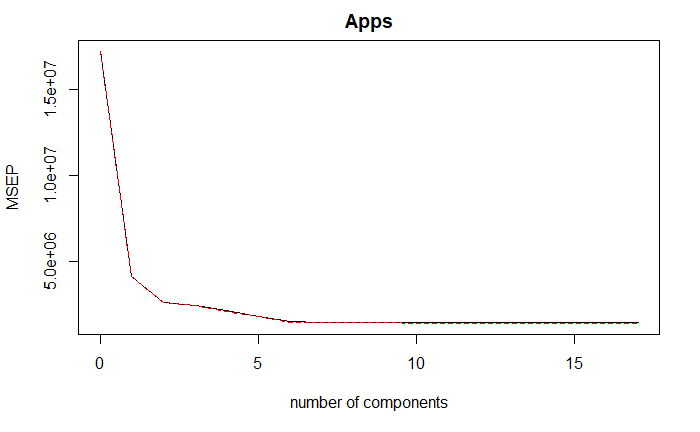

```r
validationplot(pls.fit,val.type = "MSEP")
```

```r
pls.pred = predict(pls.fit,x.testmat,ncomp = 7)
mean((pls.pred-y[-sample])^2)
```

```
[1] 1014764
```

Plotting out the bar graph, we should see lasso and ridge regression having comparable results, as both are better than the linear fit. PLS and PCR models both did worse than linear regression. If given the choice, i’d choose fitting this with the lasso regression, as the interpretation of the model would be easier as lasso regression performs variable selection.

```r
error <- c(mean((lm.pred - test$Apps)^2), mean((ridge.pred-test$Apps)^2), mean((lasso.pred - test$Apps)^2), mean((pcr.pred-test$Apps)^2), mean((pls.pred-test$Apps)^2))
error
```

```
[1]  996667.4  992828.6  993791.1 1031142.3 1014764.3
```

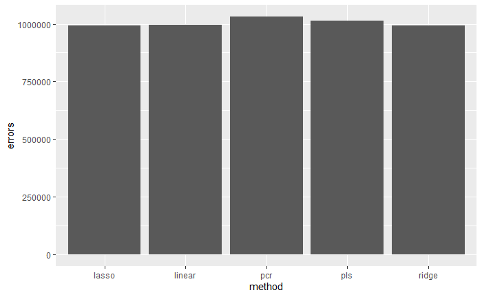

```r
bars <- tribble(
  ~method,     ~errors,
  "linear",error[1],
  "ridge", error[2],
  "lasso", error[3],
  "pcr", error[4],
  "pls",error[5]
)
ggplot(data = bars) +
  geom_bar(mapping = aes(x = method, y = errors), stat = "identity")
```